# HW5

Donovan Kott

2023-10-21

```r
data2 <- read.csv("C:/Users/dmkot/Downloads/Unemployment in America Per US State.csv")
str(data2)
```

```
## 'data.frame':    29892 obs. of  11 variables:
##  $ FIPS.Code                                                : int  1 2 4 5 6 37 8 9 10 11 ...
##  $ State.Area                                               : chr  "Alabama" "Alaska" "Arizona" "Arkansas" ...
##  $ Year                                                     : int  1976 1976 1976 1976 1976 1976 1976 1976 1976 1976 ...
##  $ Month                                                    : int  1 1 1 1 1 1 1 1 1 1 ...
##  $ Total.Civilian.Non.Institutional.Population.in.State.Area: chr  "2,605,000   " "232,000   " "1,621,000   " "1,536,000   " ...
##  $ Total.Civilian.Labor.Force.in.State.Area                 : chr  "1,484,555   " "160,183   " "964,120   " "889,044   " ...
##  $ Percent.....of.State.Area.s.Population                   : num  57 69 59.5 57.9 62.6 64.1 67.2 64.2 62.7 64.4 ...
##  $ Total.Employment.in.State.Area                           : chr  "1,386,023   " "148,820   " "865,871   " "824,395   " ...
##  $ Percent.....of.Labor.Force.Employed.in.State.Area        : num  53.2 64.1 53.4 53.7 56.8 58.4 63.3 57.9 57.7 58.8 ...
##  $ Total.Unemployment.in.State.Area                         : chr  "98,532   " "11,363   " "98,249   " "64,649   " ...
##  $ Percent.....of.Labor.Force.Unemployed.in.State.Area      : num  6.6 7.1 10.2 7.3 9.2 8.9 5.8 9.8 8 8.7 ...
```

```r
data3 = data2[data2$State.Area == "New Jersey",]
head(data3)
```

```
##     FIPS.Code State.Area Year Month
## 32         34 New Jersey 1976     1
## 85         34 New Jersey 1976     2
## 138        34 New Jersey 1976     3
## 191        34 New Jersey 1976     4
## 244        34 New Jersey 1976     5
## 297        34 New Jersey 1976     6
##     Total.Civilian.Non.Institutional.Population.in.State.Area
## 32                                               5,358,000
## 85                                               5,363,000
## 138                                              5,367,000
## 191                                              5,372,000
## 244                                              5,376,000
## 297                                              5,381,000
##     Total.Civilian.Labor.Force.in.State.Area
```

[output cut: 34 more lines]

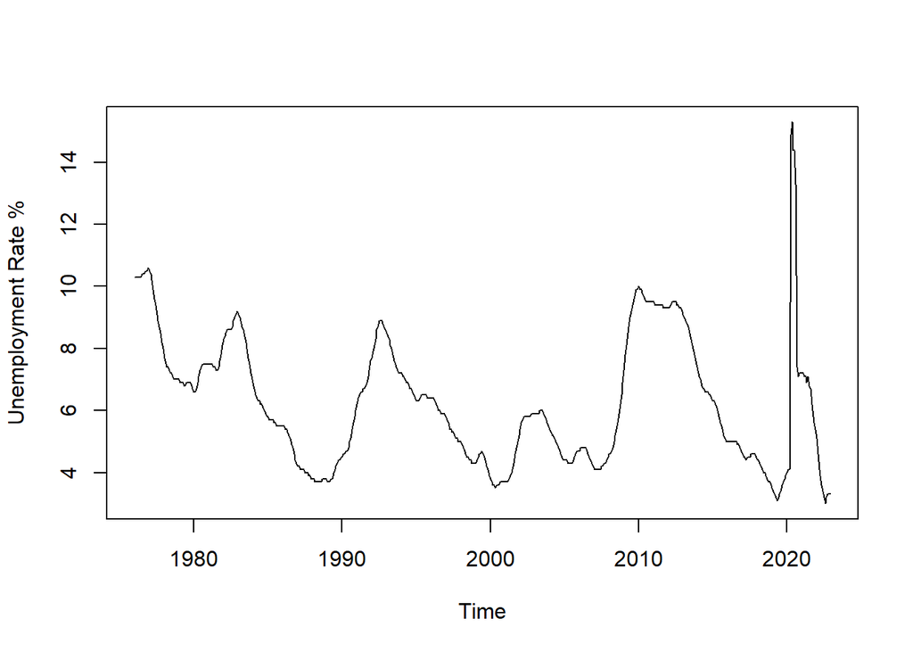

```r
myts = ts(data3$Percent.....of.Labor.Force.Unemployed.in.State.Area, start=c(1976,1), end=c(2022,12), frequency=12)
plot(myts, ylab="Unemployment Rate %")
```

```r
library(fpp)
library(fpp2)
```

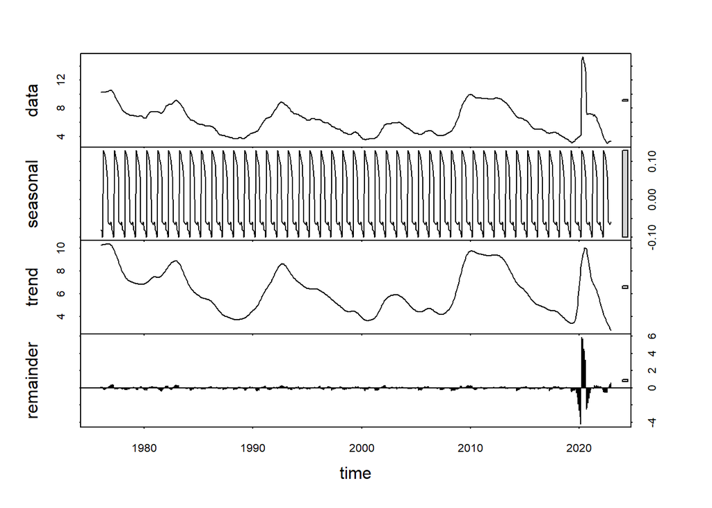

```r
stl_decomp <- stl(myts,s.window ="periodic")
plot(stl_decomp)
```

```r
attributes(stl_decomp)
```

```
## $names
## [1] "time.series" "weights"     "call"        "win"         "deg"
## [6] "jump"        "inner"       "outer"
##
## $class
## [1] "stl"
```

Even looking at the printed out seasonally adjusted data you can see the true values are not that far off from the seasonally adjusted values. It begs the question that Unemployment data is already seasonally adjusted or not?

```r
# Lets print out a seasonal adjustment
seasadj(stl_decomp)
```

```
##            Jan       Feb       Mar       Apr       May       Jun       Jul
## 1976 10.379522 10.382778 10.398799 10.170953 10.179277 10.194394 10.307384
## 1977 10.579522 10.482778 10.298799  9.770953  9.479277  9.294394  9.007384
## 1978  7.779522  7.682778  7.498799  7.270953  7.179277  7.094394  7.107384
## 1979  7.079522  6.982778  6.998799  6.770953  6.679277  6.694394  6.807384
## 1980  6.679522  6.682778  6.798799  6.770953  6.979277  7.194394  7.307384
## 1981  7.579522  7.582778  7.598799  7.370953  7.279277  7.294394  7.207384
## 1982  8.379522  8.482778  8.598799  8.470953  8.479277  8.494394  8.507384
## 1983  9.179522  9.082778  8.998799  8.570953  8.479277  8.294394  8.107384
## 1984  6.879522  6.782778  6.598799  6.270953  6.179277  6.194394  6.107384
## 1985  5.879522  5.782778  5.798799  5.570953  5.579277  5.494394  5.507384
## 1986  5.579522  5.582778  5.498799  5.270953  5.179277  5.094394  5.007384
## 1987  4.279522  4.282778  4.198799  3.970953  3.979277  3.994394  3.907384
## 1988  3.879522  3.882778  3.798799  3.570953  3.579277  3.594394  3.607384
## 1989  3.779522  3.782778  3.798799  3.670953  3.679277  3.894394  4.007384
```

[output cut: 81 more lines]

```r
myts
```

```
##       Jan  Feb  Mar  Apr  May  Jun  Jul  Aug  Sep  Oct  Nov  Dec
## 1976 10.3 10.3 10.3 10.3 10.3 10.3 10.4 10.4 10.4 10.5 10.5 10.6
## 1977 10.5 10.4 10.2  9.9  9.6  9.4  9.1  8.9  8.7  8.5  8.2  8.0
## 1978  7.7  7.6  7.4  7.4  7.3  7.2  7.2  7.1  7.0  7.0  7.0  7.0
## 1979  7.0  6.9  6.9  6.9  6.8  6.8  6.9  6.9  6.9  6.9  6.8  6.7
## 1980  6.6  6.6  6.7  6.9  7.1  7.3  7.4  7.5  7.5  7.5  7.5  7.5
## 1981  7.5  7.5  7.5  7.5  7.4  7.4  7.3  7.3  7.4  7.6  7.8  8.1
## 1982  8.3  8.4  8.5  8.6  8.6  8.6  8.6  8.7  8.9  9.0  9.1  9.2
## 1983  9.1  9.0  8.9  8.7  8.6  8.4  8.2  8.0  7.7  7.5  7.2  7.0
## 1984  6.8  6.7  6.5  6.4  6.3  6.3  6.2  6.2  6.1  6.0  5.9  5.8
## 1985  5.8  5.7  5.7  5.7  5.7  5.6  5.6  5.5  5.5  5.5  5.5  5.5
## 1986  5.5  5.5  5.4  5.4  5.3  5.2  5.1  4.9  4.8  4.6  4.4  4.3
## 1987  4.2  4.2  4.1  4.1  4.1  4.1  4.0  4.0  4.0  3.9  3.9  3.8
## 1988  3.8  3.8  3.7  3.7  3.7  3.7  3.7  3.7  3.8  3.8  3.8  3.8
## 1989  3.7  3.7  3.7  3.8  3.8  4.0  4.1  4.2  4.3  4.4  4.4  4.5
```

[output cut: 33 more lines]

Once again you see the same thing. The seasonally adjusted data is plotted alongside the time series and the black (ts) and red (seasonally adjusted) lines are almost exactly the same. If the time series data wasn’t already seasonally adjusted you would see a greater difference between the red and black lines.

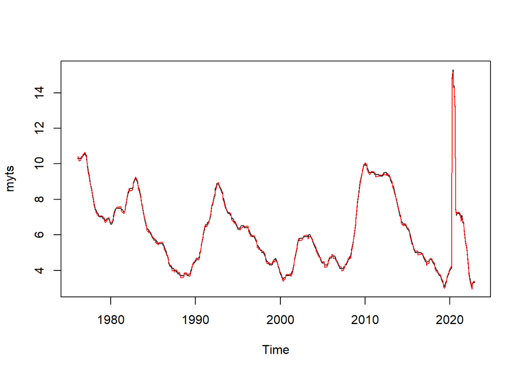

```r
# Plot a line on the graph
plot(myts)
lines(seasadj(stl_decomp), col="Red")
```

```r
# you can pass the # of period
f_stl <- forecast(stl_decomp,h=48)
f_stl
```

```
##          Point Forecast       Lo 80    Hi 80        Lo 95     Hi 95
## Jan 2023       3.279919  2.59703794 3.962800  2.235542462  4.324296
## Feb 2023       3.276663  2.31097173 4.242355  1.799765512  4.753561
## Mar 2023       3.260641  2.07793539 4.443347  1.451848654  5.069434
## Apr 2023       3.488488  2.12282771 4.854147  1.399891044  5.577084
## May 2023       3.480164  1.95331756 5.007011  1.145053850  5.815274
## Jun 2023       3.465046  1.79247552 5.137617  0.907069945  6.023023
## Jul 2023       3.452057  1.64547772 5.258635  0.689132676  6.214980
## Aug 2023       3.419811  1.48850057 5.351122  0.466126535  6.373496
## Sep 2023       3.300332  1.25187057 5.348793  0.167480657  6.433183
## Oct 2023       3.296833  1.13756805 5.456099 -0.005478004  6.599145
## Nov 2023       3.293335  1.02868046 5.557990 -0.170155265  6.756825
## Dec 2023       3.300001  0.93464788 5.665353 -0.317494246  6.917496
## Jan 2024       3.279919  0.81798350 5.741855 -0.485286511  7.045125
## Feb 2024       3.276663  0.72179329 5.831533 -0.630673177  7.184000
## Mar 2024       3.260641  0.61610100 5.905182 -0.783834122  7.305117
## Apr 2024       3.488488  0.75721913 6.219756 -0.688627043  7.665602
## May 2024       3.480164  0.66483803 6.295490 -0.825505542  7.785834
## Jun 2024       3.465046  0.56810084 6.361992 -0.965449541  7.895542
## Jul 2024       3.452057  0.47572869 6.428384 -1.099844092  8.003957
## Aug 2024       3.419811  0.36616397 6.473458 -1.250339173  8.089961
## Sep 2024       3.300332  0.17127544 6.429388 -1.485146974  8.085811
## Oct 2024       3.296833  0.09414279 6.499524 -1.601259236  8.194926
## Nov 2024       3.293335  0.01866548 6.568005 -1.714839884  8.301510
## Dec 2024       3.300001 -0.04509936 6.645101 -1.815888354  8.415890
## Jan 2025       3.279919 -0.13415870 6.693997 -1.941462341  8.501301
## Feb 2025       3.276663 -0.20502613 6.758353 -2.048121157  8.601448
## Mar 2025       3.260641 -0.28737133 6.808654 -2.165575817  8.686859
## Apr 2025       3.488488 -0.12463126 7.101606 -2.037300837  9.014276
## May 2025       3.480164 -0.19690829 7.157236 -2.143432810  9.103761
## Jun 2025       3.465046 -0.27488593 7.204979 -2.254686558  9.184780
## Jul 2025       3.452057 -0.34969673 7.253810 -2.362223332  9.266336
## Aug 2025       3.419811 -0.44277369 7.282396 -2.487502556  9.327125
## Sep 2025       3.300332 -0.62214115 7.222805 -2.698572930  9.299237
## Oct 2025       3.296833 -0.68462707 7.278294 -2.792284958  9.385952
## Nov 2025       3.293335 -0.74625171 7.332922 -2.884679776  9.471350
## Dec 2025       3.300001 -0.79688774 7.396889 -2.965649459  9.565651
## Jan 2026       3.279919 -0.87348042 7.433319 -3.072157337  9.631996
## Feb 2026       3.276663 -0.93248885 7.485815 -3.160679370  9.714006
## Mar 2026       3.260641 -1.00353434 7.524817 -3.260852625  9.782135
## Apr 2026       3.488488 -0.83001080 7.806986 -3.116085736 10.093061
## May 2026       3.480164 -0.89198204 7.852310 -3.206456370 10.166784
## Jun 2026       3.465046 -0.96009700 7.890190 -3.302626463 10.232719
## Jul 2026       3.452057 -1.02545709 7.929570 -3.395709628 10.299823
## Aug 2026       3.419811 -1.10946717 7.949089 -3.507122253 10.346744
## Sep 2026       3.300332 -1.28012607 7.880790 -3.704874040 10.305538
## Oct 2026       3.296833 -1.33423860 7.927905 -3.785780051 10.379447
## Nov 2026       3.293335 -1.38780387 7.974474 -3.865849136 10.452519
## Dec 2026       3.300001 -1.43067529 8.030677 -3.934943875 10.534945
```

```r
f_stl$method
```

```
## [1] "STL +  ETS(A,N,N)"
```

```r
accuracy(f_stl)
```

```
##                       ME      RMSE       MAE        MPE    MAPE      MASE
## Training set -0.01248346 0.5319094 0.1403864 -0.3614053 2.16185 0.1267887
##                   ACF1
## Training set 0.1192229
```

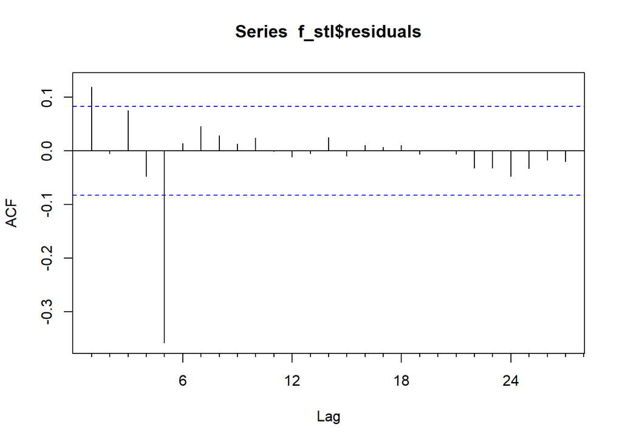

```r
Acf(f_stl$residuals)
```

I can see the forecast for the next 48 months since that is the parameter I set for “h”. The forecast is very steady but the confidence interval shows it has a wide range to go up or down.

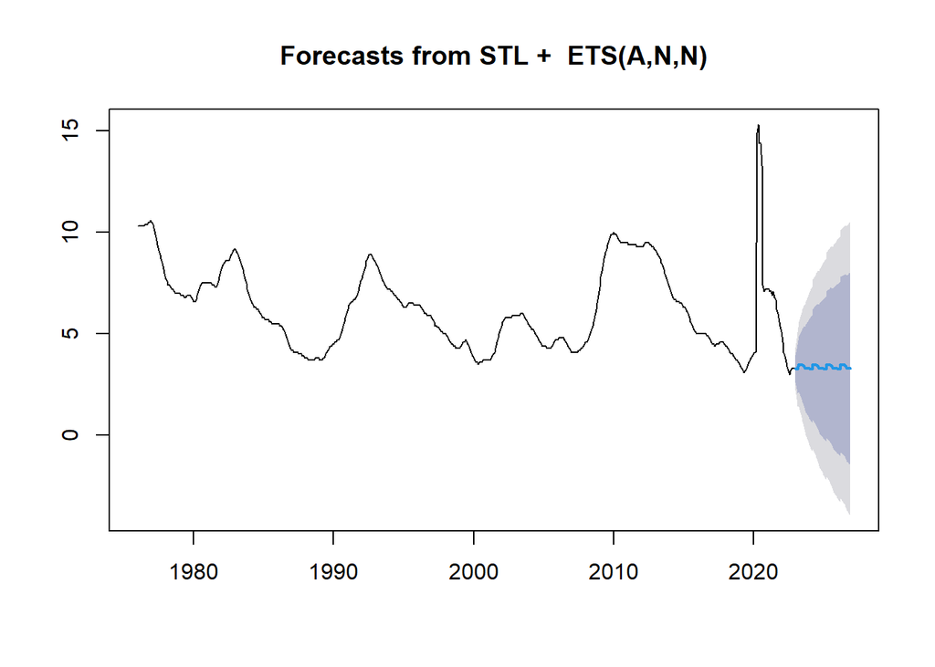

```r
plot(f_stl)
```

```r
# There is more than one way to do things
decomp_myts <- decompose(myts)
```

Our data is an Additive time series meaning this model works best when the time series being analyzed has roughly the same variability throughout the length of the series. The value of the time series falls usually within a band of constant width centered around a trend and is represented as the sum of components.

This is just another way of decomposing and shows similar points as the plot earlier in this paper.

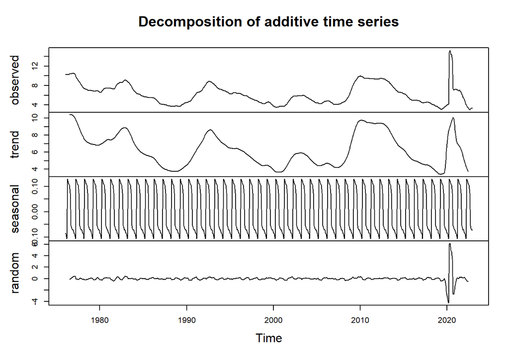

```r
plot(decomp_myts)
```

We can use the “type” name to confirm its an Additive model.

```r
# Each one shows different attributes
attributes(decomp_myts)
```

```
## $names
## [1] "x"        "seasonal" "trend"    "random"   "figure"   "type"
##
## $class
## [1] "decomposed.ts"
```

```r
decomp_myts$figure
```

```
##  [1] -0.08426932 -0.08843599 -0.10564614  0.12913647  0.12261473  0.10966184
##  [7]  0.10540459  0.07397343 -0.05437802 -0.06470411 -0.07240338 -0.07095411
```

```r
decomp_myts$type
```

```
## [1] "additive"
```

```r
seasadj(decomp_myts)
```

```
##            Jan       Feb       Mar       Apr       May       Jun       Jul
## 1976 10.384269 10.388436 10.405646 10.170864 10.177385 10.190338 10.294595
## 1977 10.584269 10.488436 10.305646  9.770864  9.477385  9.290338  8.994595
## 1978  7.784269  7.688436  7.505646  7.270864  7.177385  7.090338  7.094595
## 1979  7.084269  6.988436  7.005646  6.770864  6.677385  6.690338  6.794595
## 1980  6.684269  6.688436  6.805646  6.770864  6.977385  7.190338  7.294595
## 1981  7.584269  7.588436  7.605646  7.370864  7.277385  7.290338  7.194595
## 1982  8.384269  8.488436  8.605646  8.470864  8.477385  8.490338  8.494595
## 1983  9.184269  9.088436  9.005646  8.570864  8.477385  8.290338  8.094595
## 1984  6.884269  6.788436  6.605646  6.270864  6.177385  6.190338  6.094595
## 1985  5.884269  5.788436  5.805646  5.570864  5.577385  5.490338  5.494595
## 1986  5.584269  5.588436  5.505646  5.270864  5.177385  5.090338  4.994595
## 1987  4.284269  4.288436  4.205646  3.970864  3.977385  3.990338  3.894595
## 1988  3.884269  3.888436  3.805646  3.570864  3.577385  3.590338  3.594595
## 1989  3.784269  3.788436  3.805646  3.670864  3.677385  3.890338  3.994595
```

[output cut: 81 more lines]

```r
x=forecast(seasadj(decomp_myts))
```

Here we can see a forecast plot of decomposed time series that is seasonally adjusted,

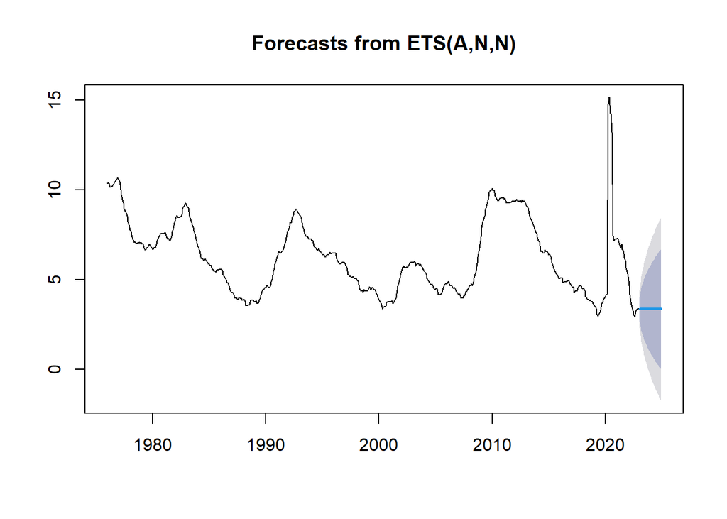

```r
plot(x)
```